# DATA 624: Homework 10

Andrew Bowen

2024-04-26

```r
library(tidyverse)
library(caret)
library(arules)
```

```r
# Read in file from BB posting
data <- read.transactions("https://learn-us-east-1-prod-fleet02-xythos.content.blackboardcdn.com/61aab133e7df2/15994286?X-Blackboard-S3-Bucket=learn-us-east-1-prod-fleet01-xythos&X-Blackboard-Expiration=1714154400000&X-Blackboard-Signature=EXNbsp64188aDjV5ghvpIntldSZyodmooKdARIQis%2Bs%3D&X-Blackboard-Client-Id=100211&X-Blackboard-S3-Region=us-east-1&response-cache-control=private%2C%20max-age%3D21600&response-content-disposition=inline%3B%20filename%2A%3DUTF-8%27%27GroceryDataSet.csv&response-content-type=text%2Fcsv&X-Amz-Security-Token=IQoJb3JpZ2luX2VjEHYaCXVzLWVhc3QtMSJHMEUCIQCPzoozXPE1F4nXsIGTwWl5%2FKQ2WV1Lvj8P77kujmDfFgIgGLl3RYlXs2RPhBOEechJ2e75alzuSmnEDkIjsXAGMEoqvQUIv%2F%2F%2F%2F%2F%2F%2F%2F%2F%2F%2FARADGgw2MzU1Njc5MjQxODMiDFtXL4Jkwt65okwHxiqRBR%2Bm8NJuX3%2FeT81Xh%2BOa%2FCTSnAbnFIpY9qgdBVxBS1uvaxRGtm%2FECck%2BrXiPvFzG0z4XdNx1x4joRiWSkQgYO7QVOltxsCGSsDPj8Lre85MmyHsT25DhcTf1ieRl%2BSzKDwljW%2Bh2klESX1pMaWIKW4HOvypaNPcWrLlBqXpb44pW4yo7m4dJqnpgOmldN%2FzAEAAcoJYlPQQxdvbDo5k0naI%2Ffw5o9nJJkK76oJQF2WQ0rC5Cf3groL0HIMDtkLT%2FYItLtxsYy5n1k3or6meEKhFovEeW3jaIOH23X4Cl1dqj3X%2FGO7XwYg7ru5C9t5f84WpjGSKNO0DuJb090I1J6lT%2FFcZeoSSWgsySropjeB%2B499%2BXkSrPPKB81Zc9fRT0yiDNBdZfD0cdMEVNLy%2BmKKuS5%2BJk5sb3ZoIa0%2F8GLb9jgwqVLwELtN%2B0jJIwLxXB3fEe%2Fi2q4bcyzJ1K2za3Sfj7VAiggDcYxbK%2FH%2BdrP5Vv433C%2BgtJKCP2nLaLLWfrqUcILs6t8%2B%2B15tbDbW7jD%2FM4WvGplummBa1VRcDeT7%2Frvk8oDQU8LhB6D1fH4viBb17SzNQYIwh4Ix6KcRjIPmCAbOpV2IAT42hGgTKkoaugmKCdSxs%2F3Q20tN7ZVADsRpz34TvAMfqOWnk8jDHF7IZUrHuDp9Y%2BrrlwmVf7skK3cRZcnzJ%2FnpW267%2Fgqkl%2FcvBau1hYUZfRNRhrL9%2B4SeOMwROACwlBkIat4jDtIio7GEJOZTwIRu0R%2F5X05oBEW99QqeDtW0JRFeCbLgNE2hf9PQ2TaBqNF3KdqAtCsbkHJTLa%2B%2FbroYdmOSH6EOxFrQYzcNMtyxBcoR6TEL9yrSNZ8U0ltb0uSkN1URue%2B5nf6DDT266xBjqxAenwDmGoi%2BXKOet8wunv6iHxx9uAGmdzj9A61u86JYR25vAA3w1v2vFPlwpsbgi3hDm1EltjIGmAwpnI%2FQhmms2cxA8sYdcMbdVuNQ3N4J6CtSs76G47WaVn%2BxYxe8uJKoTEZPXPg9GwosEnqLERltXlql4RO3%2BPHDwrq4F0tS0zbFBsKVPs%2FQz5I7s%2FtmE2HRJ2WplMVXQFMshwkuUUY9Pqa40WxJVN7O96kvew7RquEg%3D%3D&X-Amz-Algorithm=AWS4-HMAC-SHA256&X-Amz-Date=20240426T120000Z&X-Amz-SignedHeaders=host&X-Amz-Expires=21600&X-Amz-Credential=ASIAZH6WM4PL6OFBYI4R%2F20240426%2Fus-east-1%2Fs3%2Faws4_request&X-Amz-Signature=ccc7803bceb51d061e6b1ab78934216319096403228d1a48247b4054bd3c92a1", sep=",")


head(data)
```

```
## transactions in sparse format with
##  6 transactions (rows) and
##  169 items (columns)
```

```r
# Print a summary of our transaction set
summary(data)
```

```
## transactions as itemMatrix in sparse format with
##  9835 rows (elements/itemsets/transactions) and
##  169 columns (items) and a density of 0.02609146
##
## most frequent items:
##       whole milk other vegetables       rolls/buns             soda
##             2513             1903             1809             1715
##           yogurt          (Other)
##             1372            34055
##
## element (itemset/transaction) length distribution:
## sizes
##    1    2    3    4    5    6    7    8    9   10   11   12   13   14   15   16
## 2159 1643 1299 1005  855  645  545  438  350  246  182  117   78   77   55   46
##   17   18   19   20   21   22   23   24   26   27   28   29   32
##   29   14   14    9   11    4    6    1    1    1    1    3    1
##
##    Min. 1st Qu.  Median    Mean 3rd Qu.    Max.
##   1.000   2.000   3.000   4.409   6.000  32.000
##
## includes extended item information - examples:
##             labels
## 1 abrasive cleaner
## 2 artif. sweetener
## 3   baby cosmetics
```

Given that our dataset is a list of transactions without a label we’re trying to predict (a very common unsupervised learning task) we can use association rules to mine this data for helpful insights. I found [*Practical Machine Learning in R* Chapter 11](https://www.wiley.com/en-us/Practical+Machine+Learning+in+R-p-9781119591535) to be a really helpful resource on association rules (and unsupervised learnign more broadly). Specifically, we can use the [A Priori Algorithm](https://www.geeksforgeeks.org/apriori-algorithm/) from the `arules` library, which is a very commonly-used association rule mining algorithm.

```r
rules <-
   apriori(data,
          parameter = list(
          support = 0.0085,
          confidence = 0.5,
          minlen = 2
        ))
```

```
## Apriori
##
## Parameter specification:
##  confidence minval smax arem  aval originalSupport maxtime support minlen
##         0.5    0.1    1 none FALSE            TRUE       5  0.0085      2
##  maxlen target  ext
##      10  rules TRUE
##
## Algorithmic control:
##  filter tree heap memopt load sort verbose
##     0.1 TRUE TRUE  FALSE TRUE    2    TRUE
##
## Absolute minimum support count: 83
##
## set item appearances ...[0 item(s)] done [0.00s].
## set transactions ...[169 item(s), 9835 transaction(s)] done [0.00s].
## sorting and recoding items ... [96 item(s)] done [0.00s].
## creating transaction tree ... done [0.00s].
## checking subsets of size 1 2 3 4 done [0.00s].
## writing ... [28 rule(s)] done [0.00s].
## creating S4 object  ... done [0.00s].
```

```r
summary(rules)
```

```
## set of 28 rules
##
## rule length distribution (lhs + rhs):sizes
##  2  3
##  1 27
##
##    Min. 1st Qu.  Median    Mean 3rd Qu.    Max.
##   2.000   3.000   3.000   2.964   3.000   3.000
##
## summary of quality measures:
##     support           confidence        coverage            lift
##  Min.   :0.008541   Min.   :0.5000   Min.   :0.01434   Min.   :1.957
##  1st Qu.:0.009354   1st Qu.:0.5162   1st Qu.:0.01759   1st Qu.:2.025
##  Median :0.010219   Median :0.5278   Median :0.01871   Median :2.164
##  Mean   :0.011344   Mean   :0.5425   Mean   :0.02108   Mean   :2.243
##  3rd Qu.:0.012405   3rd Qu.:0.5737   3rd Qu.:0.02430   3rd Qu.:2.292
##  Max.   :0.022267   Max.   :0.6389   Max.   :0.04342   Max.   :3.030
##      count
##  Min.   : 84.0
##  1st Qu.: 92.0
##  Median :100.5
##  Mean   :111.6
##  3rd Qu.:122.0
##  Max.   :219.0
##
## mining info:
##  data ntransactions support confidence
##  data          9835  0.0085        0.5
##                                                                                    call
##  apriori(data = data, parameter = list(support = 0.0085, confidence = 0.5, minlen = 2))
```

We can also use the `inspect` function and some dply magic to get the top-10 rules by lift, along with each rule’s support and confidence

```r
rules %>%
   sort(by = "lift") %>%
   head(n = 10) %>%
   inspect()
```

```
##      lhs                     rhs                    support confidence   coverage     lift count
## [1]  {citrus fruit,
##       root vegetables}    => {other vegetables} 0.010371124  0.5862069 0.01769192 3.029608   102
## [2]  {root vegetables,
##       tropical fruit}     => {other vegetables} 0.012302999  0.5845411 0.02104728 3.020999   121
## [3]  {rolls/buns,
##       root vegetables}    => {other vegetables} 0.012201322  0.5020921 0.02430097 2.594890   120
## [4]  {root vegetables,
##       whipped/sour cream} => {other vegetables} 0.008540925  0.5000000 0.01708185 2.584078    84
## [5]  {root vegetables,
##       yogurt}             => {other vegetables} 0.012913066  0.5000000 0.02582613 2.584078   127
## [6]  {butter,
##       yogurt}             => {whole milk}       0.009354347  0.6388889 0.01464159 2.500387    92
## [7]  {domestic eggs,
##       root vegetables}    => {whole milk}       0.008540925  0.5957447 0.01433655 2.331536    84
## [8]  {curd,
##       yogurt}             => {whole milk}       0.010066090  0.5823529 0.01728521 2.279125    99
## [9]  {pip fruit,
##       root vegetables}    => {whole milk}       0.008947636  0.5751634 0.01555669 2.250988    88
## [10] {curd,
##       other vegetables}   => {whole milk}       0.009862735  0.5739645 0.01718353 2.246296    97
```

To increase sales based on this ruleset, a store manager may want to consider placing vegetables next to fruits (citrus or tropical), as those items are frequently purchased together. In addition, grouping dairy products together also would help to increase complementary purchases.

### Simple Clustering Analysis

We can use the K-Means clustering method on this transaction data. First we’ll want to convert to a format suitable for clustering. In our case, each row will represent one transaction, with the column values representing items and whetehr or not they were purchased (`1`) or not (`0`) in a given transaction

```r
# Convert the transactions dataset to a quasi-adjacency matrix, multiply by 1 to convert booleans to 0/1
df <-  1 * as(data,"matrix")
```

Now that we have our transactions as suitable feature vectors, we can try various values of $k$ to see which parititions our transaction data best. I found this [DataCamp tutorial helpful](https://www.datacamp.com/tutorial/k-means-clustering-r) for this step, using the `kmeans` function within the `stats` library.

```r
# Decide how many clusters to look at
n_clusters <- 15

# Initialize total within sum of squares error
wss <- numeric(n_clusters)

set.seed(1234)

# Look over 1 to n possible clusters
for (i in 1:n_clusters) {
  # Fit the model: km.out
  km.out <- kmeans(df, centers = i, nstart = 20)
  # Save the within cluster sum of squares
  wss[i] <- km.out$tot.withinss
}
```

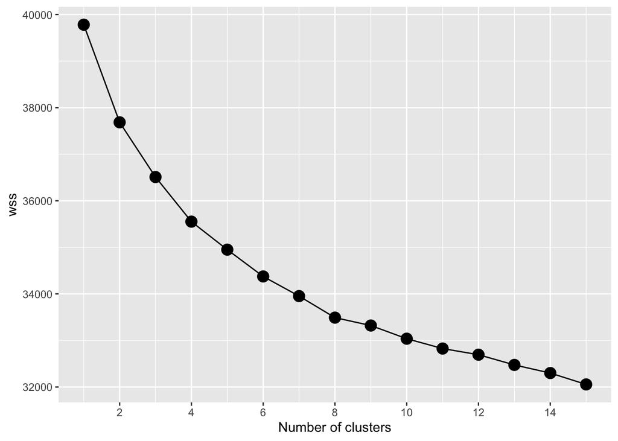

```r
# Produce a scree plot
wss_df <- tibble(clusters = 1:n_clusters, wss = wss)

scree_plot <- ggplot(wss_df, aes(x = clusters, y = wss, group = 1)) +
    geom_point(size = 4)+
    geom_line() +
    scale_x_continuous(breaks = seq(2, 15, 2)) +
    xlab('Number of clusters')
scree_plot
```

Other evaluation metrics we could use for our clusters could be the Silhouette score or the Davied-Boulding index for an unsupervised learning task